# Integration test for MRSea 2d salsa with other variables, with 1d smooth, with panels, no interactions

LAS Scott-Hayward, C Fell

2020-08-10

2020-08-09

2020-08-10

## Introduction

This is the seventh in a series of tests that can be used to check changes to the MRSea package do not break previously working elements. They replicate the case study in the vignette but broken down into chunks. This seventh one checks the 2D salsa functions with other variables, with a 1d smooth, with panels and no interactions.

```r
count.data <- read.csv("1.count.data.csv")
data <- count.data
data$response <- round(data$NHAT)
data$blockid <- paste(data$transect.id, data$season, data$impact,sep = "")
attach(data)
```

## Set up

Set a prediction grid.

Set up the initial model with factor covariates and offset term

```r
initialModel <- glm(response ~ 1 + offset(log(area)), family = "quasipoisson", data = data)
```

```r
salsa1dlist <- list(
  fitnessMeasure = "cv.gamMRSea",
  minKnots_1d = 2,
  maxKnots_1d = 5,
  startKnots_1d = 1,
  degree = 2,
  maxIterations = 10,
  gaps = c(0),
  cv.opts=list(cv.gamMRSea.seed=1, K=10)
)
```

```r
# run SALSA
set.seed(1234)
salsa1dOutput <- runSALSA1D(initialModel, salsa1dlist, c("depth"), predictionData=predictData,
datain=data, removal=TRUE, panelid = data$blockid)
```

Number of knots selected for depth: 1 this should be 1.

Location of knot selected for depth: -12.212 this should be -12.212.

## Selection of flexibility for 2D smooth term

Create a grid of knots that will be used as possible knot locations.

```r
knotgrid <- read.csv("4.knotgrid.csv")
```

Sum of knotgrid: 2018630 this should be 2018630.

Sum of datadist: 8224.849 this should be 8224.849.

Sum of knotdist: 1775357 this should be 1775357.

Set Salsa2D parameters.

```r
# make parameter set for running salsa2d
salsa2dlist<-list(
  fitnessMeasure = 'cv.gamMRSea',
  knotgrid = knotgrid,
  startKnots=5,
  minKnots=4,
  maxKnots=12,
  gap=0,
  cv.opts=list(cv.gamMRSea.seed=1, K=10)
)
```

Run SALSA2D to find the appropriate number and location of knots for the 2D smooth term of `x.pos` and `y.pos`.

```r
start_time <- Sys.time()
set.seed(1234)
salsa2dOutput<-runSALSA2D(salsa1dOutput$bestModel, salsa2dlist, d2k=distMats$dataDist,
k2k=distMats$knotDist, panels = data$blockid, suppress.printout=TRUE)
total_time <- Sys.time() - start_time
```

## Predictions compared to original

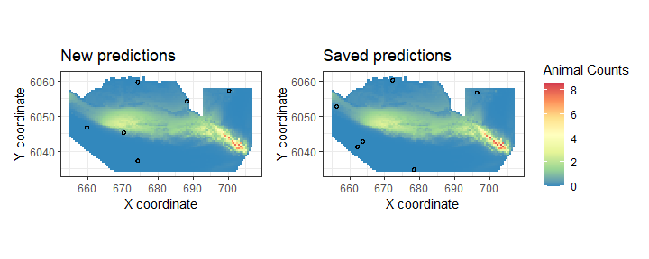

```
[1] "warning: no offset included as link response specified"
```

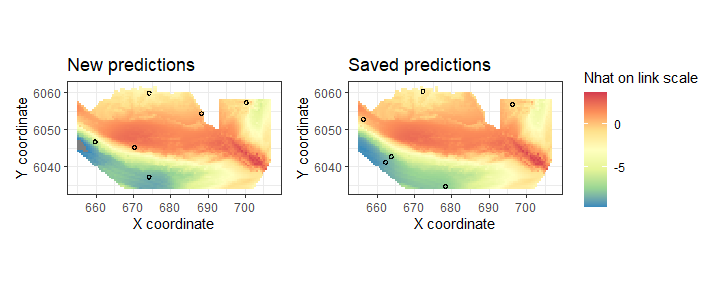

Sum of all predictions on response scale: 2203.845 this should be 2201.378.

Sum of all predictions on link scale: -8350.405 this should be -7843.877.

Time for training: 14.4 Original time: 13.4.

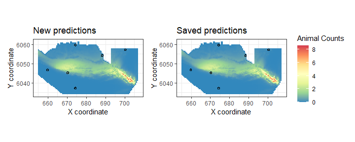

```
[1] "warning: no offset included as link response specified"
```

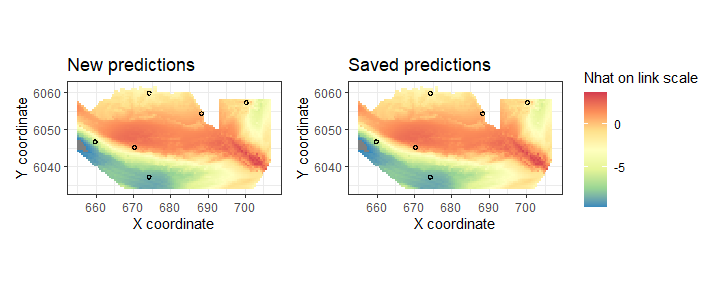

Sum of all predictions on response scale: 2203.845 this should be 2203.845.

Sum of all predictions on link scale: -8350.405 this should be -8350.405.

Time for training: 12.5 Original time: 13.4.

Number of model fits: 408 Original model fits: 408

New coefficients

|  | Estimate | Std. Error | Robust S.E. | t value | Pr(>\|t\|) |
| --- | --- | --- | --- | --- | --- |
| (Intercept) | -5.137 | 6.589 | 4.230 | -1.214 | 0.225 |
| s(depth)1 | 4.009 | 7.171 | 4.807 | 0.834 | 0.404 |
| s(depth)2 | 13.921 | 6.423 | 4.055 | 3.433 | 0.001 |
| s(depth)3 | 10.965 | 6.707 | 4.479 | 2.448 | 0.014 |
| s(x.pos, y.pos)b1 | -4.901 | 1.174 | 0.743 | -6.595 | 0.000 |
| s(x.pos, y.pos)b2 | -10.591 | 1.544 | 1.002 | -10.572 | 0.000 |
| s(x.pos, y.pos)b3 | -5.590 | 0.787 | 0.774 | -7.220 | 0.000 |
| s(x.pos, y.pos)b4 | 1.758 | 1.049 | 0.693 | 2.536 | 0.011 |
| s(x.pos, y.pos)b5 | -9.487 | 1.902 | 1.362 | -6.963 | 0.000 |
| s(x.pos, y.pos)b6 | 11.233 | 1.897 | 1.492 | 7.528 | 0.000 |

Saved coefficients

| X | Estimate | Std..Error | Robust.S.E. | t.value | Pr…t.. |
| --- | --- | --- | --- | --- | --- |
| (Intercept) | -5.137 | 6.589 | 4.230 | -1.214 | 0.225 |
| s(depth)1 | 4.009 | 7.171 | 4.807 | 0.834 | 0.404 |
| s(depth)2 | 13.921 | 6.423 | 4.055 | 3.433 | 0.001 |
| s(depth)3 | 10.965 | 6.707 | 4.479 | 2.448 | 0.014 |
| s(x.pos, y.pos)b1 | -4.901 | 1.174 | 0.743 | -6.595 | 0.000 |
| s(x.pos, y.pos)b2 | -10.591 | 1.544 | 1.002 | -10.572 | 0.000 |
| s(x.pos, y.pos)b3 | -5.590 | 0.787 | 0.774 | -7.220 | 0.000 |
| s(x.pos, y.pos)b4 | 1.758 | 1.049 | 0.693 | 2.536 | 0.011 |
| s(x.pos, y.pos)b5 | -9.487 | 1.902 | 1.362 | -6.963 | 0.000 |
| s(x.pos, y.pos)b6 | 11.233 | 1.897 | 1.492 | 7.528 | 0.000 |

Standard errors are not equal to robust standard errors: TRUE

Dispersion: 23.69341 this should be 25.57402.

Mean square error: 0.4287839 this should be 0.4363444.

residual sum square error to data: 5.911513 this should be 11.5113.

Sum of all estimates: 6.178555 this should be 6.178555.

Sum of all robust SE: 23.6371 this should be 23.6371.

Standard errors are not equal to robust standard errors: TRUE

Dispersion: 23.69341 this should be 23.69341.

Mean square error: 0.4287839 this should be 0.4287839.

residual sum square error to data: 5.911513 this should be 5.911513.

Mean square error to truth seen: 0.4704165 this should be 0.4704165.

Mean square error to truth unseen: 0.41539 this should be 0.41539.